# Milestone_1_Final_Project

Prerna Sehgal

11/12/2019

## Proposed Analysis

I want to look at binding pattern differences between the WT and mutant Runx2. For this I have four questions that I want to answer: 1. What regulatory elements are bound by the WT and the mutant? 2. Runx2 WT and mutant binding to TSS regions? 3. How is the enrichment of the protein binding affected across the chromosomes for WT and mutant? 4. Functional enrichment analysis for WT and mutant?

I will be using the ChIP-seq specific R Bioconductor packages to do my ChIP-seq analysis.

```r
library(ChIPseeker)
library(TxDb.Hsapiens.UCSC.hg38.knownGene)
txdb <- TxDb.Hsapiens.UCSC.hg38.knownGene
library(clusterProfiler)
```

## Proposed Timeline & Major milestones (or segments).

Milestone 1 (11/14/2019): Get familiar with using the ChIPseeker package by working with a known data set. Try to get the result for the first two problems. Milestone 2 (11/21/2019): Continue with understanding the package and answer the last two questions. Milestone 3 (11/27/2019): Optimizing the results and overcome any road blocks hit. Submit a rough draft for QA. Milestone 4 (12/06/2019): Address the QA problems and make the final draft. Submit the final project.

## Milestone 1

I am still trying to understand the ChiPseeker vignette with a known data set. I was able to answer the first two questions but I still have to work on them to look asthetically beautiful.

1. What regulatory elements are bound by the WT and the mutant? ## Loading files

```r
files <- getSampleFiles()
print(files)
```

```
## $ARmo_0M
## [1] "/Library/Frameworks/R.framework/Versions/3.6/Resources/library/ChIPseeker/extdata/GEO_sample_data/GSM1174480_ARmo_0M_peaks.bed.gz"
##
## $ARmo_1nM
## [1] "/Library/Frameworks/R.framework/Versions/3.6/Resources/library/ChIPseeker/extdata/GEO_sample_data/GSM1174481_ARmo_1nM_peaks.bed.gz"
##
## $ARmo_100nM
## [1] "/Library/Frameworks/R.framework/Versions/3.6/Resources/library/ChIPseeker/extdata/GEO_sample_data/GSM1174482_ARmo_100nM_peaks.bed.gz"
##
## $CBX6_BF
## [1] "/Library/Frameworks/R.framework/Versions/3.6/Resources/library/ChIPseeker/extdata/GEO_sample_data/GSM1295076_CBX6_BF_ChipSeq_mergedReps_peaks.bed.gz"
##
## $CBX7_BF
## [1] "/Library/Frameworks/R.framework/Versions/3.6/Resources/library/ChIPseeker/extdata/GEO_sample_data/GSM1295077_CBX7_BF_ChipSeq_mergedReps_peaks.bed.gz"
```

```r
files
```

```
## $ARmo_0M
## [1] "/Library/Frameworks/R.framework/Versions/3.6/Resources/library/ChIPseeker/extdata/GEO_sample_data/GSM1174480_ARmo_0M_peaks.bed.gz"
##
## $ARmo_1nM
## [1] "/Library/Frameworks/R.framework/Versions/3.6/Resources/library/ChIPseeker/extdata/GEO_sample_data/GSM1174481_ARmo_1nM_peaks.bed.gz"
##
## $ARmo_100nM
## [1] "/Library/Frameworks/R.framework/Versions/3.6/Resources/library/ChIPseeker/extdata/GEO_sample_data/GSM1174482_ARmo_100nM_peaks.bed.gz"
##
## $CBX6_BF
## [1] "/Library/Frameworks/R.framework/Versions/3.6/Resources/library/ChIPseeker/extdata/GEO_sample_data/GSM1295076_CBX6_BF_ChipSeq_mergedReps_peaks.bed.gz"
##
## $CBX7_BF
## [1] "/Library/Frameworks/R.framework/Versions/3.6/Resources/library/ChIPseeker/extdata/GEO_sample_data/GSM1295077_CBX7_BF_ChipSeq_mergedReps_peaks.bed.gz"
```

```r
peak <- readPeakFile(files[[4]])
peak
```

```
## GRanges object with 1331 ranges and 2 metadata columns:
##          seqnames              ranges strand |             V4        V5
##             <Rle>           <IRanges>  <Rle> |       <factor> <numeric>
##      [1]     chr1       815093-817883      * |    MACS_peak_1    295.76
##      [2]     chr1     1243288-1244338      * |    MACS_peak_2     63.19
##      [3]     chr1     2979977-2981228      * |    MACS_peak_3    100.16
##      [4]     chr1     3566182-3567876      * |    MACS_peak_4    558.89
##      [5]     chr1     3816546-3818111      * |    MACS_peak_5     57.57
##      ...      ...                 ...    ... .            ...       ...
##   [1327]     chrX 135244783-135245821      * | MACS_peak_1327     55.54
##   [1328]     chrX 139171964-139173506      * | MACS_peak_1328    270.19
##   [1329]     chrX 139583954-139586126      * | MACS_peak_1329    918.73
##   [1330]     chrX 139592002-139593238      * | MACS_peak_1330    210.88
##   [1331]     chrY   13845134-13845777      * | MACS_peak_1331     58.39
##   -------
##   seqinfo: 24 sequences from an unspecified genome; no seqlengths
```

```r
P1 <- data.frame(peak)
setwd("~/desktop/files/peaks")
f1 <- readPeakFile("IP-WT_S13_vs_Input-WT_S15_peaks.chrfiltered.bed")
f2 <- readPeakFile("IP-4RK_S16_vs_Input-4RK_S14_peaks.chrfiltered.bed")
f1
```

```
## GRanges object with 30382 ranges and 7 metadata columns:
##           seqnames            ranges strand |
##              <Rle>         <IRanges>  <Rle> |
##       [1]     chr1     187048-187097      * |
##       [2]     chr1     821654-821718      * |
##       [3]     chr1     893131-893241      * |
##       [4]     chr1     941153-941279      * |
##       [5]     chr1     962053-962134      * |
##       ...      ...               ...    ... .
##   [30378]     chrY 11309288-11309340      * |
##   [30379]     chrY 11723291-11723340      * |
##   [30380]     chrY 56839406-56839513      * |
##   [30381]     chrY 56859046-56859131      * |
##   [30382]     chrY 56872203-56872316      * |
##                                             V4        V5       V6
```

[output cut: 27 more lines]

```r
f2
```

```
## GRanges object with 21342 ranges and 7 metadata columns:
##           seqnames              ranges strand |
##              <Rle>           <IRanges>  <Rle> |
##       [1]     chr1       821866-822059      * |
##       [2]     chr1       902280-902590      * |
##       [3]     chr1       910054-910295      * |
##       [4]     chr1       923967-924311      * |
##       [5]     chr1       924473-924801      * |
##       ...      ...                 ...    ... .
##   [21338]     chrX 153609919-153610163      * |
##   [21339]     chrX 153695971-153696164      * |
##   [21340]     chrX 153767367-153767746      * |
##   [21341]     chrX 153934732-153934925      * |
##   [21342]     chrY   56860461-56860667      * |
##                                               V4        V5       V6
```

[output cut: 27 more lines]

```r
wildtype <- data.frame(f1)
mutant <- data.frame(f2)
```

## Regulatory regions

```r
txdb1 = TxDb.Hsapiens.UCSC.hg38.knownGene
peakAnno <- annotatePeak(f1, tssRegion=c(-3000, 3000),
                         TxDb=txdb1)
```

```
## >> preparing features information...      2019-11-14 09:24:08
## >> identifying nearest features...        2019-11-14 09:24:09
## >> calculating distance from peak to TSS...   2019-11-14 09:24:11
## >> assigning genomic annotation...        2019-11-14 09:24:11
## >> assigning chromosome lengths           2019-11-14 09:24:42
## >> done...                    2019-11-14 09:24:42
```

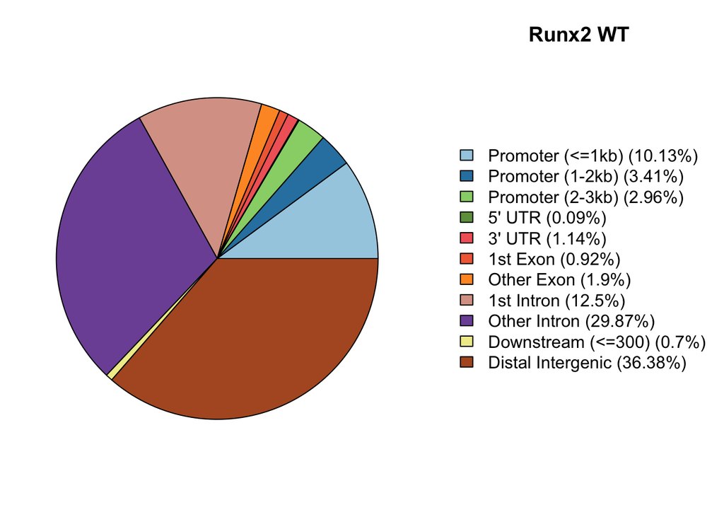

```r
plotAnnoPie(peakAnno)
title(main = "Runx2 WT", line = -2)
```

```r
peakAnno1 <- annotatePeak(f2, tssRegion=c(-3000, 3000),
                         TxDb=txdb1)
```

```
## >> preparing features information...      2019-11-14 09:24:42
## >> identifying nearest features...        2019-11-14 09:24:42
## >> calculating distance from peak to TSS...   2019-11-14 09:24:42
## >> assigning genomic annotation...        2019-11-14 09:24:42
## >> assigning chromosome lengths           2019-11-14 09:24:47
## >> done...                    2019-11-14 09:24:47
```

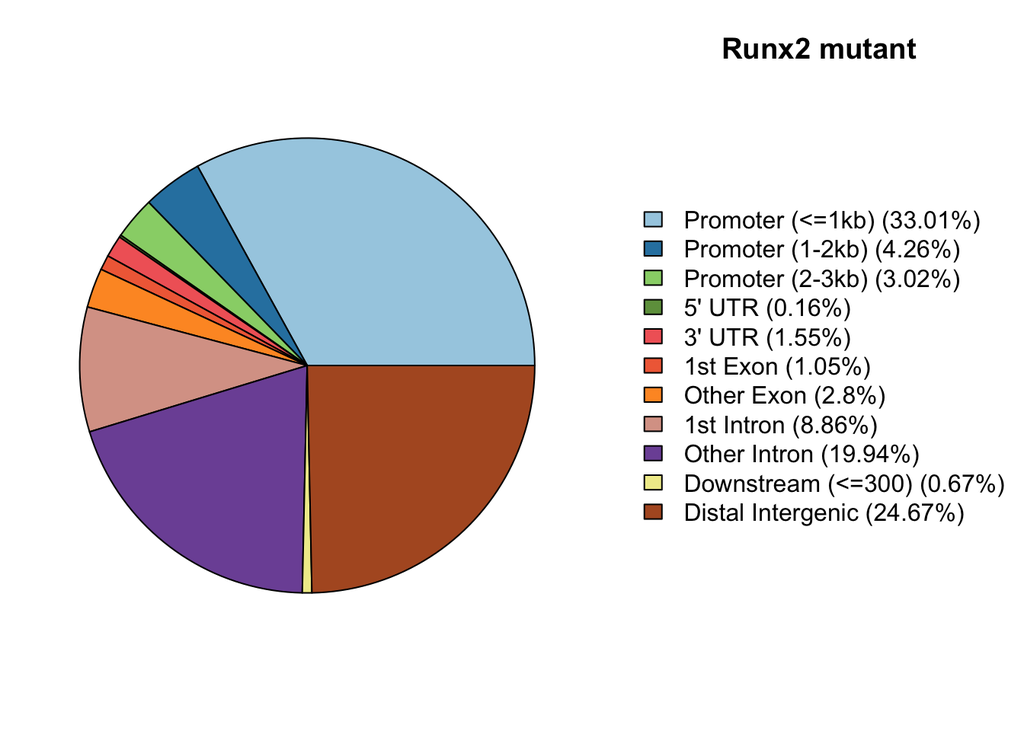

```r
plotAnnoPie(peakAnno1)
title(main = "Runx2 mutant", line = -2)
```

## TSS plots

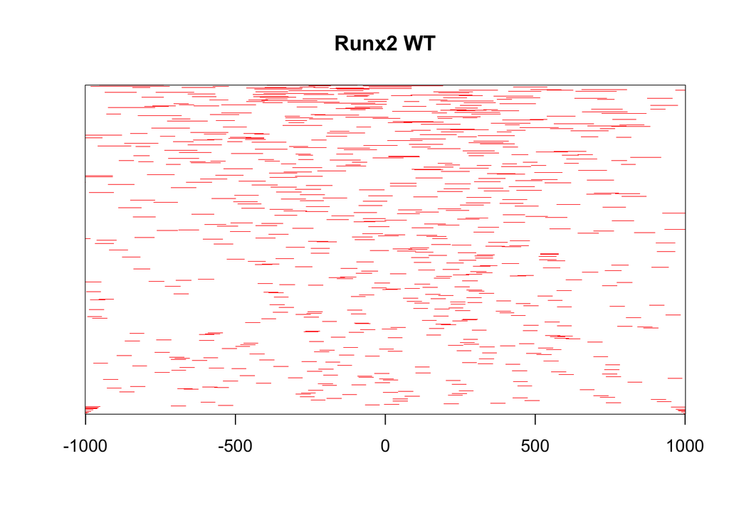

```r
txdb1 = TxDb.Hsapiens.UCSC.hg38.knownGene
promoter <- getPromoters(TxDb = txdb1, upstream=1000, downstream=1000)
tagMatrix <- getTagMatrix(f1, windows=promoter)
tagHeatmap(tagMatrix, xlim=c(-1000, 1000), color="red")
title(main = "Runx2 WT")
```

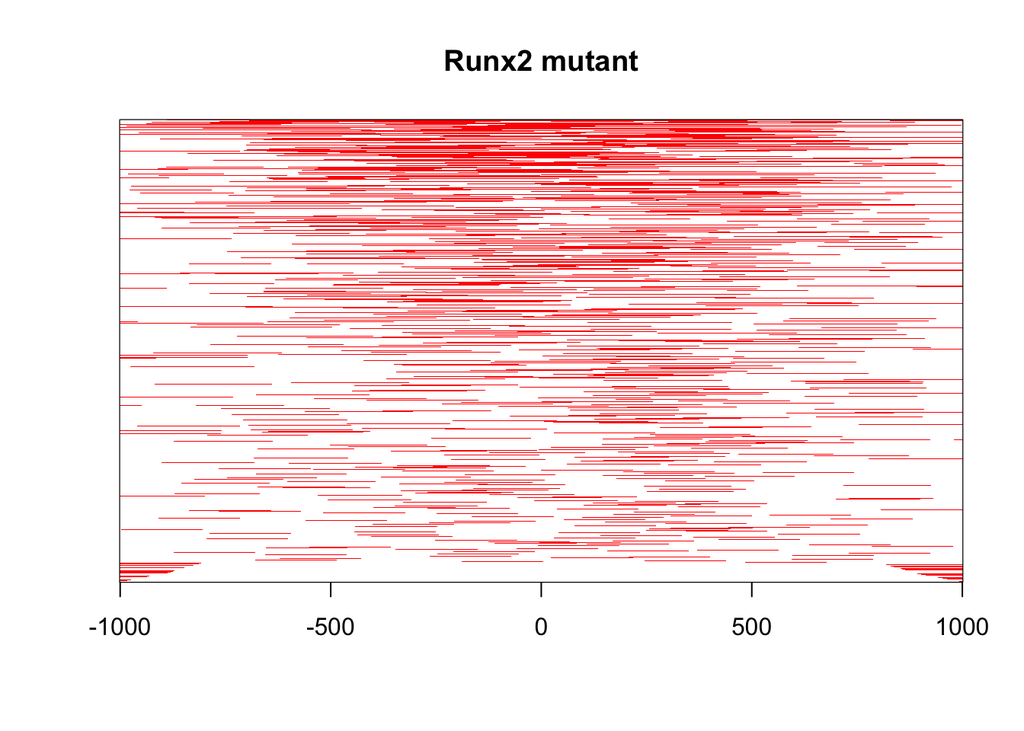

```r
tagMatrix1 <- getTagMatrix(f2, windows=promoter)
tagHeatmap(tagMatrix1, xlim=c(-1000, 1000), color="red")
title(main = "Runx2 mutant")
```